# HW3

Author

Clara Bowman

```r
library(dplyr)
library(knitr)
library(tidytext)
library(ggplot2)
library(textdata)
```

```r
pubmed <- read.csv('pubmed.csv')
```

# Text Mining

## 1. Most Common Words

### Number of Abstracts for Each Search Term

```r
table(pubmed$term)
```

```
          covid cystic fibrosis      meningitis    preeclampsia prostate cancer
            981             376             317             780             787
```

There are 5 search terms with between 317 and 981 abstracts.

### Tokenize Abstracts

```r
tokens <- pubmed %>%
  unnest_tokens(token, abstract)
tokens %>% count(token, sort=TRUE) %>% head(10)
```

```
   token     n
1    the 28126
2     of 24760
3    and 19993
4     in 14653
5     to 10920
6      a  8245
7   with  8038
8  covid  7275
9     19  7080
10    is  5649
```

The most common tokens are stop words. ‘covid’ and ‘19’ are the most common tokens that are not stop words.

### Top 5 words by search term

```r
tokens %>%
  group_by(term) %>%
  count(token) %>%
  top_n(5,n)
```

```
# A tibble: 25 × 3
# Groups:   term [5]
   term            token     n
   <chr>           <chr> <int>
 1 covid           19     7035
 2 covid           and    6861
 3 covid           covid  7275
 4 covid           of     7668
 5 covid           the    9741
 6 cystic fibrosis and    1777
 7 cystic fibrosis in     1497
 8 cystic fibrosis of     2304
 9 cystic fibrosis the    2677
10 cystic fibrosis to     1011
# ℹ 15 more rows
```

Most of the top 5 words for each term are stop words. Covid includes ‘covid’ and ‘19’ and ‘prostate’ and ‘cancer’ are among the top 5 words for prostate cancer.

## 2. Removing Stop Words

```r
tokens_no_stop <- tokens %>%
  anti_join(stop_words, by=c('token'='word'))
tokens_no_stop %>%
  count(token, sort=TRUE) %>% head(10)
```

```
          token    n
1         covid 7275
2            19 7080
3      patients 4674
4        cancer 3999
5      prostate 3832
6       disease 2574
7           pre 2165
8     eclampsia 2005
9  preeclampsia 1863
10    treatment 1841
```

Stop words have been removed, so ‘covid’, ‘19’, ‘patients’, ‘cancer’ and ‘prostate’ are the 5 most common words overall, and most words seem to be medically relevant.

### Top 5 words by search term (no stop words)

```r
tokens_no_stop %>%
  group_by(term) %>%
  count(token) %>%
  top_n(5,n)
```

```
# A tibble: 25 × 3
# Groups:   term [5]
   term            token        n
   <chr>           <chr>    <int>
 1 covid           19        7035
 2 covid           covid     7275
 3 covid           disease    943
 4 covid           pandemic   800
 5 covid           patients  2293
 6 cystic fibrosis cf         625
 7 cystic fibrosis cystic     862
 8 cystic fibrosis disease    400
 9 cystic fibrosis fibrosis   867
10 cystic fibrosis patients   586
# ℹ 15 more rows
```

## 3. Tokenize into bigrams

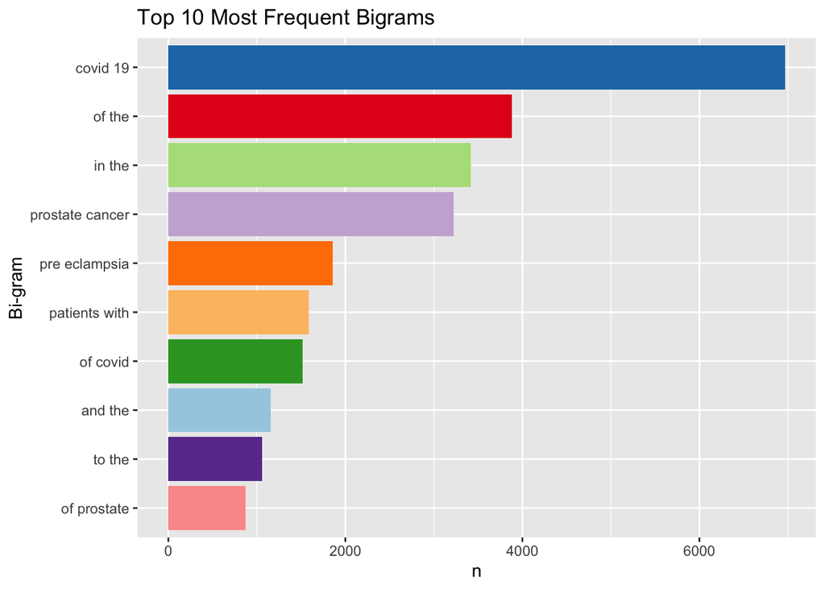

```r
bigrams <- pubmed %>%
  unnest_ngrams(bigram, abstract, n=2) %>%
  count(bigram, sort=TRUE)
bigrams %>%
  top_n(n = 10, wt = n) %>%
  ggplot(aes(x = n, y = reorder(bigram, n), fill = bigram)) +
  geom_col() +
  scale_fill_brewer(palette = "Paired") +
  labs(title = "Top 10 Most Frequent Bigrams", y = "Bi-gram") +
  theme(legend.position = 'none')
```

## 4. TF-IDF By Search Term

```r
tf_idf<-tokens %>%
  count(token,term) %>%
  bind_tf_idf(token, term, n) %>%
  arrange(term, desc(tf_idf))

tf_idf %>%
  group_by(term) %>%
  top_n(5, tf_idf)
```

```
# A tibble: 25 × 6
# Groups:   term [5]
   token       term                n      tf   idf  tf_idf
   <chr>       <chr>           <int>   <dbl> <dbl>   <dbl>
 1 covid       covid            7275 0.0371  1.61  0.0597
 2 pandemic    covid             800 0.00408 1.61  0.00657
 3 coronavirus covid             647 0.00330 1.61  0.00531
 4 sars        covid             372 0.00190 1.61  0.00305
 5 cov         covid             334 0.00170 1.61  0.00274
 6 cf          cystic fibrosis   625 0.0127  0.916 0.0117
 7 fibrosis    cystic fibrosis   867 0.0176  0.511 0.00901
 8 cystic      cystic fibrosis   862 0.0175  0.511 0.00896
 9 cftr        cystic fibrosis    86 0.00175 1.61  0.00282
10 sweat       cystic fibrosis    83 0.00169 1.61  0.00272
# ℹ 15 more rows
```

This list does not include stop words. Each term’s top 5 words seem specific to that term which makes sense as words that come up less frequently in other search terms are given a higher tf-idf.

# Sentiment Analysis

## 5. Using NRC Lexicon

```r
nrc_counts <- pubmed %>%
  unnest_tokens(word, abstract) %>%
  inner_join(get_sentiments('nrc'), by='word') %>%
  count(term, sentiment, sort = TRUE)
nrc_counts %>%
  group_by(term) %>%
  top_n(1, n)
```

```
# A tibble: 5 × 3
# Groups:   term [5]
  term            sentiment     n
  <chr>           <chr>     <int>
1 covid           positive   9874
2 prostate cancer negative   8918
3 preeclampsia    positive   8014
4 cystic fibrosis positive   2747
5 meningitis      negative   2109
```

“Negative” is the most common sentiment for meningitis and prostate cancer; “positive” is the most common sentiment for covid, cystic fibrosis and preclampsia.

```r
nrc_counts %>%
  filter(sentiment!='positive' & sentiment!='negative') %>%
  group_by(term) %>%
  top_n(1, n)
```

```
# A tibble: 5 × 3
# Groups:   term [5]
  term            sentiment        n
  <chr>           <chr>        <int>
1 prostate cancer fear          8118
2 covid           fear          7730
3 preeclampsia    anticipation  4780
4 cystic fibrosis disgust       1714
5 meningitis      fear          1510
```

The most common sentiment excluding ‘positive’ and ‘negative’ is fear for prostate cancer, covid, and meningitis, anticipation for preeclampsia and disgust for cystic fibrosis.

## 6. Using AFINN Library

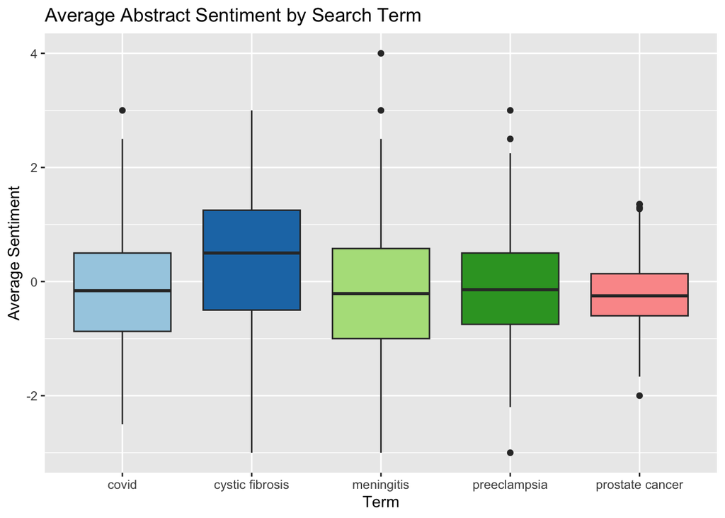

```r
afinn_abstract_avg <- pubmed %>%
  mutate(abstract_num = row_number()) %>%
  unnest_tokens(word, abstract) %>%
  inner_join(get_sentiments('afinn'), by='word') %>%
  group_by(abstract_num) %>%
  summarise(avg_sentiment=mean(value),
            term=first(term))
ggplot(afinn_abstract_avg, aes(x=term, y=avg_sentiment, fill=term)) +
  geom_boxplot() +
  labs(title='Average Abstract Sentiment by Search Term',x='Term',y='Average Sentiment') +
  scale_fill_brewer(palette = "Paired")+
  theme(legend.position = 'none')
```

All of the search terms except cystic fibrosis have an average sentiment across abstracts of slightly below zero. Cystic fibrosis stands out as the only mean above zero – abstracts for this term tend to be more positive than the rest. Additionally, prostate cancer’s abstracts have a much tighter range of average sentiment values than other terms.